# UNIT07A：離散理論機率分佈

中山大學管理學院 卓雍然

2022-03-26 02:04:48

```r
pacman::p_load(dplyr)
```

### 【1】$n$很大時，二項分佈(Binominal Dist.)會趨近於常態(Normal)分佈

- When $n$ is large, $Binom[n, p]$ approaches $Norm[\mu = n p, \sigma=\sqrt{n p (1-p)}]$
- $X \sim Binom[n, p] \, \Rightarrow \, Exp(X) = n \cdot p \, , \, Var(X) = n \cdot p \cdot (1-p)$

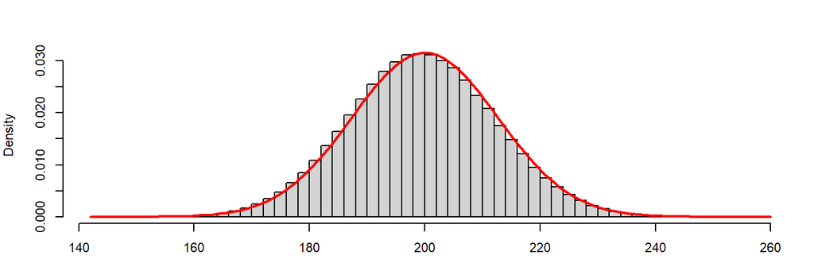

```r
par(mfrow=c(1,1), mar=c(3,4,3,1), cex=0.7)
n = 1000; p = 0.2
rbinom(500000, n, p) %>% hist(breaks=80, freq=F, main="")
curve(dnorm(x, mean=n*p, sd=sqrt(n*p*(1-p))), col='red', lwd=2, add=T)
```

```r
#add=T:加在原有的圖形上面
```

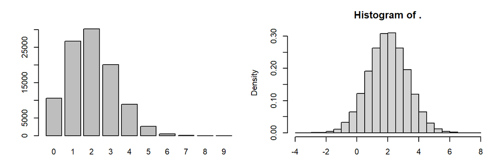

```r
par(mfrow=c(1,2), cex=0.7)
n = 10; p = 0.2
rbinom(100000, n, p) %>% table %>% barplot()
rnorm(100000, n*p, sqrt(n*p*(1-p))) %>% hist(freq=F)
```

💡 : 當期望值夠大的時候， 二項分佈會以期望值為中心向兩邊對稱的伸展，但是如果期望值不夠大的話，這個分佈的左尾就會受到擠壓，變成一個不對稱的分佈。

### 【2】$n \times p$不大時，二項分佈(Binominal Dist.)會趨近於Poisson分佈

- When $n$ is large and $p$ is small, $Binom[n, p]$ approaches $Pois[\lambda = n p]$

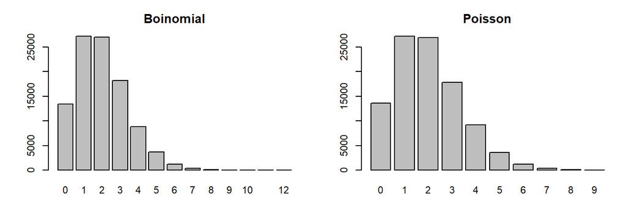

```r
par(mfrow=c(1,2), cex=0.7)
rbinom(100000, 1000, 0.002) %>% table %>% barplot(main="Boinomial")
rpois(100000, 2)  %>% table %>% barplot(main="Poisson")
```

🗿 : 如果Poisson分佈很接近二項分佈，我們為甚麼還需要Poisson分佈呢？

💡 : 簡單、一般性 vs 複雜、準確性

- $X \sim Pois[\lambda] \, \Rightarrow \, E(X) = Var(X) = \lambda$

```r
sapply(1:10, function(lambda) {
  x = rpois(1000000, lambda)
  c(mean(x), var(x))
  })
```

```
       [,1]   [,2]   [,3]   [,4]   [,5]   [,6]   [,7]   [,8]   [,9]   [,10]
[1,] 1.0016 2.0056 2.9986 3.9985 4.9999 5.9964 6.9978 7.9949 9.0008 10.0029
[2,] 1.0017 2.0084 3.0011 3.9934 4.9992 5.9953 6.9958 8.0123 9.0285  9.9906
```

- $X \sim Pois[\lambda_1], \, Y \sim Pois[\lambda_2] \, \Rightarrow \, X+Y \sim Pois[\lambda_1 + \lambda_2]$

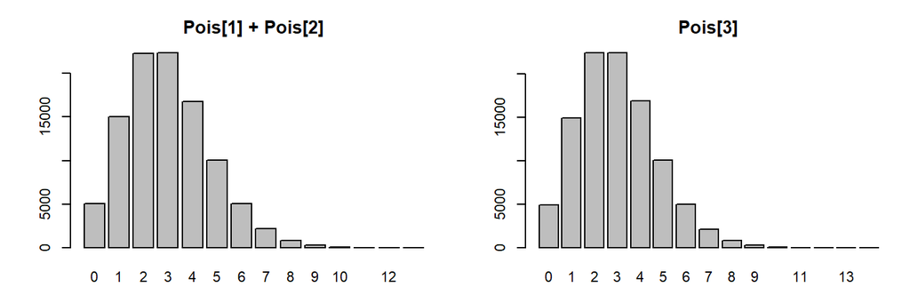

```r
par(mfrow=c(1,2), cex=0.7)
(rpois(100000, 1) + rpois(100000, 2)) %>% table %>% barplot(main="Pois[1] + Pois[2]")
rpois(100000, 3)  %>% table %>% barplot(main="Pois[3]")
```

💡 : 透過模擬：(1)建立變數向量(隨機變數)；(2)驗證理論；(3)做預測與估計

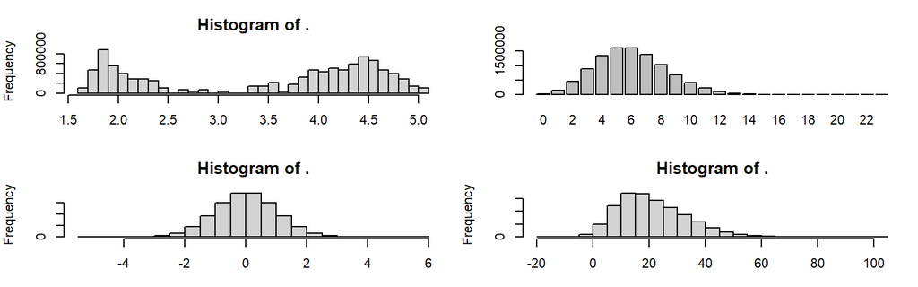

```r
K = 10000000
par(mfrow=c(2,2), cex=0.7)
d1 = sample(faithful$eruptions, K, T); d1 %>% hist
d2 = rpois(K, 6); d2 %>% table %>% barplot
d3 = rnorm(K, 0, 1); d3 %>% hist
(d1*d2+4*d3) %>% hist
```

### 【4】Geometric Dist.基本上是等待時間的分佈

我們可以用二項分佈來模擬Geometric Dist.

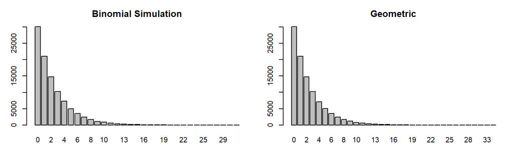

```r
par(mfrow=c(1,2), mar=c(3,3,3,1), cex=0.7)
replicate(100000, which(rbinom(100, 1, .3) == 1)[1] - 1) %>%
  table %>% barplot(main="Binomial Simulation")
rgeom(100000, 0.3) %>% table %>% barplot(main="Geometric")
```

```r
#which(rbinom(100, 1, .3) == 1)[1]):回傳第一次成功Index
```

```r
dgeom(0:20, 0.05) %>% cumsum
```

```
 [1] 0.05000 0.09750 0.14263 0.18549 0.22622 0.26491 0.30166 0.33658 0.36975
[10] 0.40126 0.43120 0.45964 0.48666 0.51233 0.53671 0.55987 0.58188 0.60279
[19] 0.62265 0.64151 0.65944
```

### 【5】Geometric Dist.的期望值

- $X \sim Geom[p] \, \Rightarrow \, E[X] = \frac{1}{p}-1$

🗿 : 如果平均而言每一個捐贈者有我需要的器官的機率是5%，那麼平均我要等多少個捐贈者才能等到我想要用的器官呢？

```r
(1/0.05)-1
```

```
[1] 19
```

🗿 : 不用Geometric的期望值公式，妳可以使用`dgeom()`算出同樣的答案嗎？

```r
sum(0:1000 * dgeom(0:1000, 0.05))
```

```
[1] 19
```

💡 數理推論為基礎的機率統計之所以難學，主要是因為：  
■ 隨機變數的觀念很抽象；  
■ 光使用數學公式很難理解『分佈』的概念；  
■ 有很多不同種類的分佈，公式記不完；  
■ 隨機變數之間要做四則運算常常非常困難；

🗿 : 在R的環境之下，我們如何克服上述的各項困難呢？ 加油!